# Analyse Stress und Vitalität im Studium

Bernhard Wittmann

20.07.2017

```r
# Daten laden
data_total <- read.table(file = "data_mindset2017.csv", encoding = "UTF-8",
    header = FALSE, sep = "\t", quote = "\"", dec = ".", row.names = "CASE",
    col.names = c("CASE", "SERIAL", "REF", "QUESTNNR", "MODE", "STARTED", "ST01_01",
        "ST01_02", "ST01_03", "ST01_04", "ST01_05", "ST01_06", "ST01_07", "ST01_08",
        "ST01_09", "ST01_10", "VT01_01", "VT01_03", "VT01_04", "VT01_05", "VT01_06",
        "VT01_07", "RF01_01", "RF01_02", "RF01_03", "RF01_04", "MS01_01", "MS01_02",
        "MS01_03", "MS01_04", "MS01_05", "MS01_06", "MS01_07", "MS01_08", "SD01",
        "SD02_01", "SD15_01", "SD15_01a", "SD16", "AG04_01", "TIME001", "TIME002",
        "TIME003", "TIME004", "TIME005", "TIME006", "TIME007", "TIME008", "TIME_SUM",
        "MAILSENT", "LASTDATA", "FINISHED", "Q_VIEWER", "LASTPAGE", "MAXPAGE",
        "MISSING", "MISSREL", "TIME_RSI", "DEG_TIME"), as.is = TRUE, colClasses = c(CASE = "numeric",
        SERIAL = "character", REF = "character", QUESTNNR = "character", MODE = "character",
        STARTED = "POSIXct", ST01_01 = "numeric", ST01_02 = "numeric", ST01_03 = "numeric",
        ST01_04 = "numeric", ST01_05 = "numeric", ST01_06 = "numeric", ST01_07 = "numeric",
        ST01_08 = "numeric", ST01_09 = "numeric", ST01_10 = "numeric", VT01_01 = "numeric",
        VT01_03 = "numeric", VT01_04 = "numeric", VT01_05 = "numeric", VT01_06 = "numeric",
        VT01_07 = "numeric", RF01_01 = "numeric", RF01_02 = "numeric", RF01_03 = "numeric",
        RF01_04 = "numeric", MS01_01 = "numeric", MS01_02 = "numeric", MS01_03 = "numeric",
        MS01_04 = "numeric", MS01_05 = "numeric", MS01_06 = "numeric", MS01_07 = "numeric",
        MS01_08 = "numeric", SD01 = "numeric", SD02_01 = "numeric", SD15_01 = "character",
        SD15_01a = "logical", SD16 = "numeric", AG04_01 = "numeric", TIME001 = "integer",
        TIME002 = "integer", TIME003 = "integer", TIME004 = "integer", TIME005 = "integer",
        TIME006 = "integer", TIME007 = "integer", TIME008 = "integer", TIME_SUM = "integer",
        MAILSENT = "POSIXct", LASTDATA = "POSIXct", FINISHED = "logical", Q_VIEWER = "logical",
        LASTPAGE = "numeric", MAXPAGE = "numeric", MISSING = "numeric", MISSREL = "numeric",
        TIME_RSI = "numeric", DEG_TIME = "numeric"), skip = 1, check.names = TRUE,
    fill = TRUE, strip.white = FALSE, blank.lines.skip = TRUE, comment.char = "",
    na.strings = "")
# nicht beendete Datensätze entfernen
data_done <- subset(data_total, MAXPAGE >= 6)
# entferne Nicht Studenten
logic_students <- (!data_done$SD15_01a & nchar(data_done$SD15_01) > 0 & (data_done$SD16 ==
    1 | data_done$SD16 == 2))
count_not_student <- nrow(subset(data_done, !logic_students))
data_stud <- subset(data_done, logic_students)
# entferne nicht gewissenhaft
min_border_gewissenhaft <- 3
count_not_gew <- nrow(subset(data_stud, AG04_01 < min_border_gewissenhaft))
data <- subset(data_stud, AG04_01 >= min_border_gewissenhaft)

decimal <- 2

# Function declaration translate öüä
translateUmlaute <- function(x) {
    x <- gsub("<e4>", "ä", x)
    x <- gsub("<f6>", "ö", x)
    x <- gsub("<fc>", "ü", x)
    return(x)
}
# tolower with exception handling
tryTolower = function(x) {
    # create missing value this is where the returned value will be
    y = ""
    test <- x
    # tryCatch error
    try_error = tryCatch(tolower(x), error = function(e) e)
    # if not an error
    if (!inherits(try_error, "error"))
        y = tolower(x)
    return(y)
}

# recode: 1,2,3,4,5 -> 5,4,3,2,1
recode = function(x) {
    return(6 - x)
}

# recodemin: 0,1,2,3,4 -> 4,3,2,1,0
recodemin = function(x) {
    return(4 - x)
}

# zentriert einen wert 1,2,3,4,5 -> -2,-1,0,1,2
center = function(x) {
    return(x - 3)
}

centerBy = function(x, by) {
    return(x - by)
}

# erstelle ein Rechteck mit Text
recttext <- function(xl, yb, xr, yt, text, rectArgs = NULL, textArgs = NULL) {
    center <- c(mean(c(xl, xr)), mean(c(yb, yt)))
    do.call("rect", c(list(xleft = xl, ybottom = yb, xright = xr, ytop = yt),
        rectArgs))
    do.call("text", c(list(x = center[1], y = center[2], labels = text), textArgs))
}

# categorize Studiengang
cat_stud = function(x) {
    x <- gsub("^\\s+|\\s+$", "", x)
    x <- gsub("-", "", x)
    x <- tolower(x)

    x <- gsub("^(tumbwl|tum bwl)$", "TUM-BWL", x)
    x <- gsub("^(psychologie|.* psychologie)$", "Psychologie", x)
    x <- gsub("^(bwl|betriebswirtschaftslehre|.*business.*|ibs|.*bwl.*|sales management)$",
        "BWL", x)
    x <- gsub("^(wirtschaftspsychologie|.*wirtschaftspsychologie.*)$", "Wirtschaftspsychologie",
        x)
    x <- gsub("^.*wirtschaftsingenieur.*$", "Wirtschaftsingenieur", x)
    x <- gsub("^.*information.*$", "Informationswissenschaften", x)
    x <- gsub("^winfo$", "Wirtschaftsinformatik", x)
    x <- gsub("^(.*lehramt.*|erwachsenenbildung)$", "Lehramt", x)
    x <- gsub("^.*biologie.*$", "Biologie", x)
    x <- gsub("^.*brau.*$", "Brauwesen", x)
    x <- gsub("^(jura|rechtswissenschaft)$", "Jura", x)
    x <- gsub("^.*marketing.*", "Marketing", x)
    x <- gsub("^.*(sport|fitness).*", "Sport", x)
    x <- gsub("^(.*kommunikation.*|kmw)", "Kommunikationswissenschaften", x)
    x <- gsub("^(.*bau.*|enb)$", "Bauwesen", x)
    x <- gsub("^(.*anglistik.*|.*englisch.*|.*english.*)$", "Anglistik", x)
    x <- gsub("^.*wirtschaftsmathematik.*$", "Wirtschaftsmathematik", x)
    x <- gsub("^(.*wirtschaft.*|vwl)$", "Wirtschaftswissenschaften", x)
    x <- gsub("^architektur$", "Architektur", x)
    x <- gsub("^physiotherapie$", "Physiotherapie", x)
    x <- gsub("^.*medien.*$", "Medienwissenschaften", x)
    x <- gsub("^.*sozi.*$", "Sozialwissenschaft", x)
    x <- gsub("^(internationale pr|human factors engineering|management)", "Management",
        x)
    x <- gsub("^(germanistik|.*deutsch.*)$", "Germanistik", x)
    x <- gsub("^.*religion.*$", "Religionswissenschaften", x)
    x <- gsub("^.*agronomie.*", "Agronomie", x)
    x <- gsub("^wissenschaft$", "Wissenschaft", x)
    x <- gsub("^.*geographie.*$", "Geographie", x)
    x <- gsub("^.*touris.*", "Tourismus", x)
    x <- gsub("^politikwissenschaften", "Politikwissenschaften", x)
    x <- gsub("^medizin", "Medizin", x)
    x <- gsub("^philosophie", "Philosophie", x)
    x <- gsub("^erziehungswissenschaft$", "Erziehungswissenschaften", x)
    x <- gsub("^kulturmanagement", "Kulturmanagement", x)
    x <- gsub("^ressortjournalismus", "Journalismus", x)
    # TODO weitere Studiengänge

    for (val in x) {
        if (val == tolower(val)) {
            warning("Achtung Studiengang nicht kategorisiert: ", val)
        }
    }
    return(x)
}

cat_stud_category = function(x) {
    x <- gsub("^(TUM-BWL|BWL|Marketing|Wirtschaftswissenschaften|Management|Jura)$",
        "Rechts- und Wirtschaftswissenschaften", x)
    x <- gsub("^(Agronomie|Brauwesen)$", "Agrar- und Forstwissenschaften", x)
    x <- gsub("^(Psychologie|Wirtschaftspsychologie|Informationswissenschaften|Sport|Kommunikationswissenschaften|Medienwissenschaften|Geographie|Tourismus|Sozialwissenschaft|Politikwissenschaften|Erziehungswissenschaften|Journalismus)$",
        "Gesellschafts- und Sozialwissenschaften", x)
    x <- gsub("^(Wirtschaftsingenieur|Bauwesen|Wirtschaftsinformatik)$", "Ingenieurwissenschaften",
        x)
    x <- gsub("^(Architektur)$", "Kunst, Gestaltung und Musik", x)
    x <- gsub("^(Lehramt)$", "Lehramtsstudiengänge", x)
    x <- gsub("^(Medizin|Physiotherapie)$", "Medizin und Gesundheitswesen",
        x)
    x <- gsub("^(Wirtschaftsmathematik|Wissenschaft|Biologie)$", "Naturwissenschaften und Mathematik
",
        x)
    x <- gsub("^(Anglistik|Germanistik|Religionswissenschaften|Philosophie|Kulturmanagement)$",
        "Sprach- und Kulturwissenschaften", x)
    return(x)
}

sub <- function(x) {
    return(x - 1)
}

# calculate growth mindset score
data <- dplyr::mutate(data, MS = (recode(MS01_01) + recode(MS01_02) + recode(MS01_04) +
    recode(MS01_06) + MS01_03 + MS01_05 + MS01_07 + MS01_08)/8)
data <- dplyr::mutate(data, MS_CENTERED = centerBy(MS, 3))

# calculate self motivation score
data <- dplyr::mutate(data, RF = sub(RF01_01) + sub(RF01_02) + sub(RF01_03) +
    sub(RF01_04))

# calculate stress level
data <- dplyr::mutate(data, ST = sub(ST01_01) + sub(ST01_02) + sub(ST01_03) +
    recodemin(sub(ST01_04)) + recodemin(sub(ST01_05)) + sub(ST01_06) + recodemin(sub(ST01_07)) +
    recodemin(sub(ST01_08)) + sub(ST01_09) + sub(ST01_10))

# calculate vitality level
data <- dplyr::mutate(data, VT = (VT01_01 + VT01_03 + VT01_04 + VT01_05 + VT01_06 +
    VT01_07)/6)

# calculate product of mindset & reframing
product <- scale(data$RF, center = FALSE) * scale(data$MS, center = FALSE)
data <- dplyr::mutate(data, RF_MS = as.vector(product))

# calculate min max achievable values for each variable
borders <- list(MS = list(MIN = 1, MAX = 5), MS_CENTERED = list(MIN = -2, MAX = 2),
    RF = list(MIN = 0, MAX = 12), ST = list(MIN = 0, MAX = 4 * 10), VT = list(MIN = 1,
        MAX = 5), RF_MS = list(MIN = floor(min(data$RF_MS)), MAX = ceiling(max(data$RF_MS))))
attach(data)
```

# Ziel

Ziel dieser Umfrage ist es Faktoren für die Stresswahrnehmung und Vitalität zu finden. Mögliche Faktoren dabei sind: das Growth Mindset der Person und die Fähigkeit der Positiven Selbstmotivierung.

> Anmerkung: Alle Ergebnisse werden auf 2 Nachkommastellen gerundet

# Deskriptive Auswertung

Zuerst soll eine deskriptive Analyse der erhobenen Daten durchgeführt werden.

## Stichprobe

Dieser Abschnitt soll die Stichprobe analysieren.

### Umfang

```r
# Berechnung Ursprungsumfang
length_total <- nrow(data_total)
# Berechnung gültiger Umfang
length <- nrow(data)
```

Der Umfang der Stichprobe beträgt insgesamt 185 Datensätze. Davon wurden insgesamt 158 gültige Fragebögen abgeschlossen.

Es wurden 7 Datensätze ausgeschlossen, weil sie nicht beendet wurden. Zudem wurden weitere 16 Datensätze ausgeschlossen, die keine StudentInnen waren. Außerdem wurden 4 Datensätze ausgeschlossen, da sie laut eigenen Angaben nicht gewissenhaft beim Ausfüllen des Fragebogens waren.

### Geschlecht

```r
# Anzahl Männer
men <- subset(data, SD01 == 2)
count_men <- nrow(men)
# Anzahl Frauen
women <- subset(data, SD01 == 1)
count_women <- nrow(women)
gender_counts <- c(count_men, count_women)
# Vektor mit Porzentangaben von Männern und Frauen
percentages_gender <- round(gender_counts/sum(gender_counts) * 100, decimal)
```

Von den insgesant 158 teilnehmenden Personen waren 47 Männer (29.75 Prozent) und 111 Frauen (70.25 Prozent).

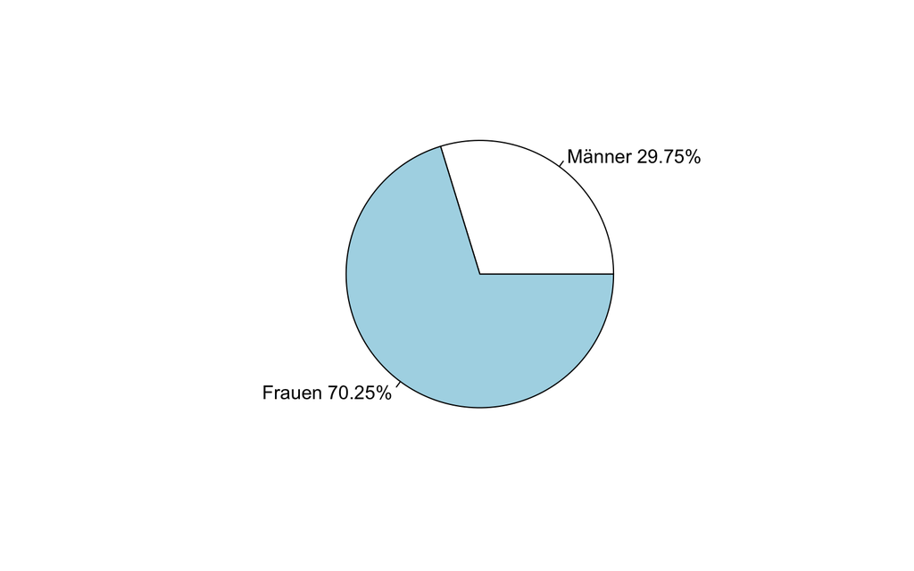

```r
labels <- c("Männer", "Frauen")

# Erstellung Kreisdiagramm aus Frauen und Männer anteil
labels <- paste(labels, percentages_gender)
labels <- paste(labels, "%", sep = "")
pie(gender_counts, labels = labels)
```

### Alter

Nun soll das Alter der teilnehmenden Personen untersucht werden. Der Mittelwert beträgt 24 Jahre und der Median liegt bei 24 Jahren. Der/Die jüngste Teilnehmer/-in ist 19 und der/die Älteste ist 46. Die Varianz hat dabei einen Wert von 14.15 mit einer Standardabweichung von 3.76.

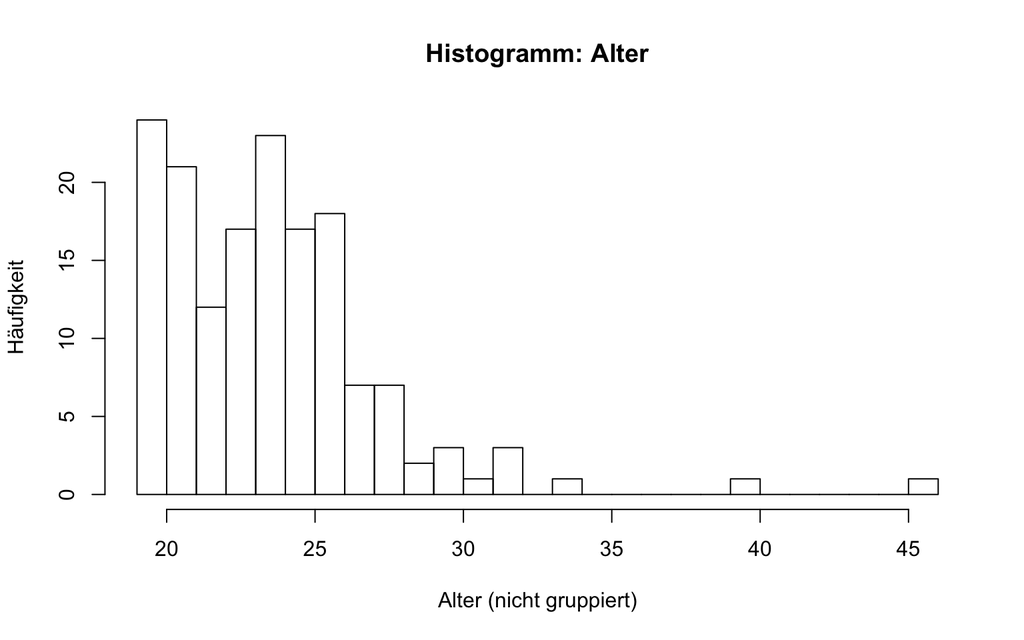

```r
# Historamm Alter
hist(SD02_01, breaks = seq(min(SD02_01), max(SD02_01), by = 1), main = "Histogramm: Alter",
    xlab = "Alter (nicht gruppiert)", ylab = "Häufigkeit")
```

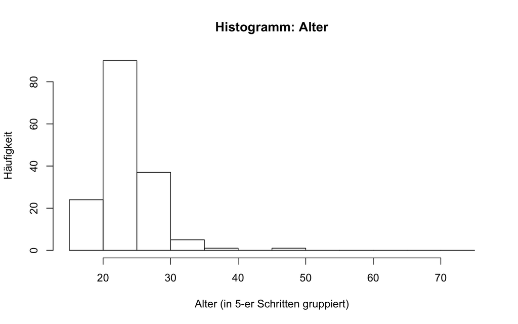

```r
# Histogramm Alter gruppiert
hist(SD02_01, breaks = seq(15, 75, by = 5), main = "Histogramm: Alter", xlab = "Alter (in 5-er Schritten gruppiert)",
    ylab = "Häufigkeit")
```

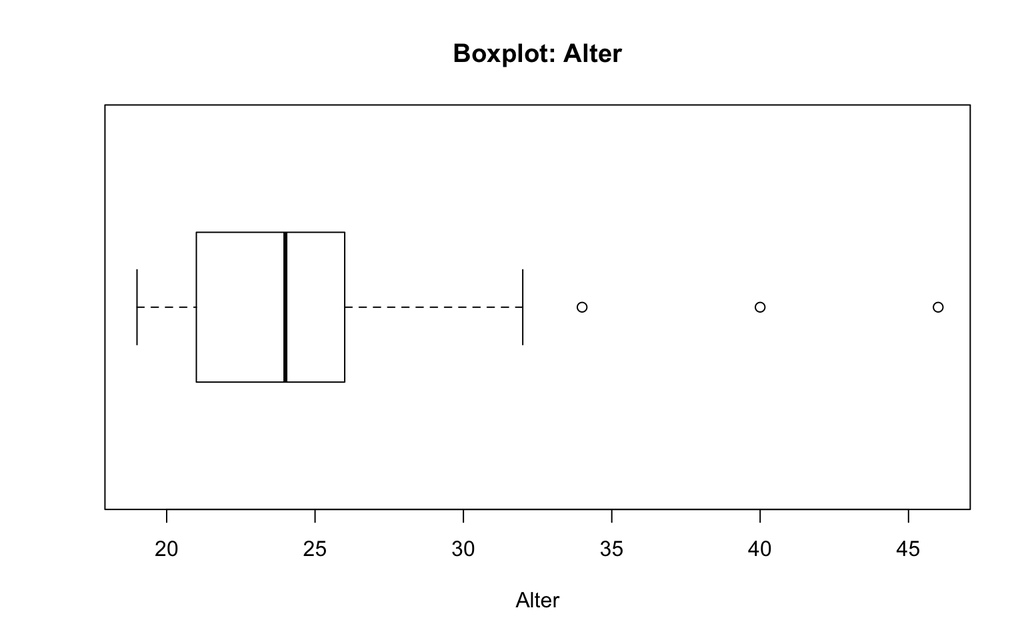

```r
# Boxplot Alter
boxplot(SD02_01, main = "Boxplot: Alter", xlab = "Alter", horizontal = TRUE)
```

```r
count_age_between_20_25 <- nrow(subset(data, SD02_01 >= 20 & SD02_01 <= 25))
percentage_age_between_20_25 <- (count_age_between_20_25/length) * 100
```

66.46 Prozent der Teilnehmer sind zwischen 20 und 25 Jahren alt.

### Studiengänge

Die Verteilung der Studiengänge soll analysiert werden

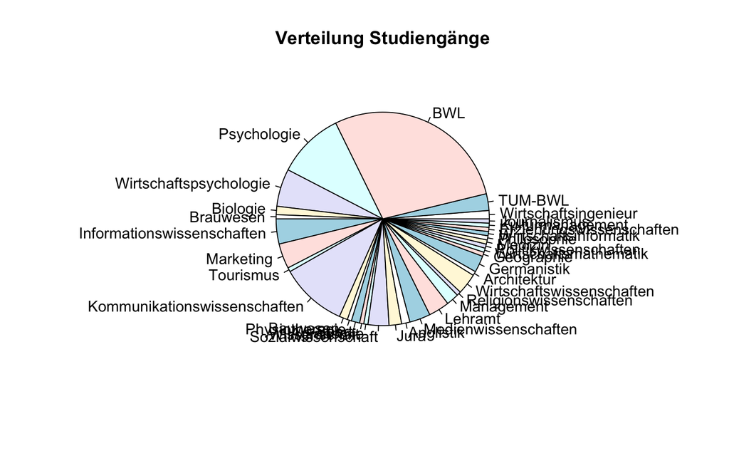

```r
# Studiengänge zusammenfassen
data <- dplyr::mutate(data, STUD = cat_stud(SD15_01))
data <- dplyr::mutate(data, STUD_CAT = cat_stud_category(STUD))
labels <- unique(data$STUD)
# Studiengänge einzeln
count_studiengaenge <- c()

for (label in labels) {
    count_studiengaenge[label] <- nrow(subset(data, STUD == label))
}

pie(count_studiengaenge, main = "Verteilung Studiengänge", labels = labels)
```

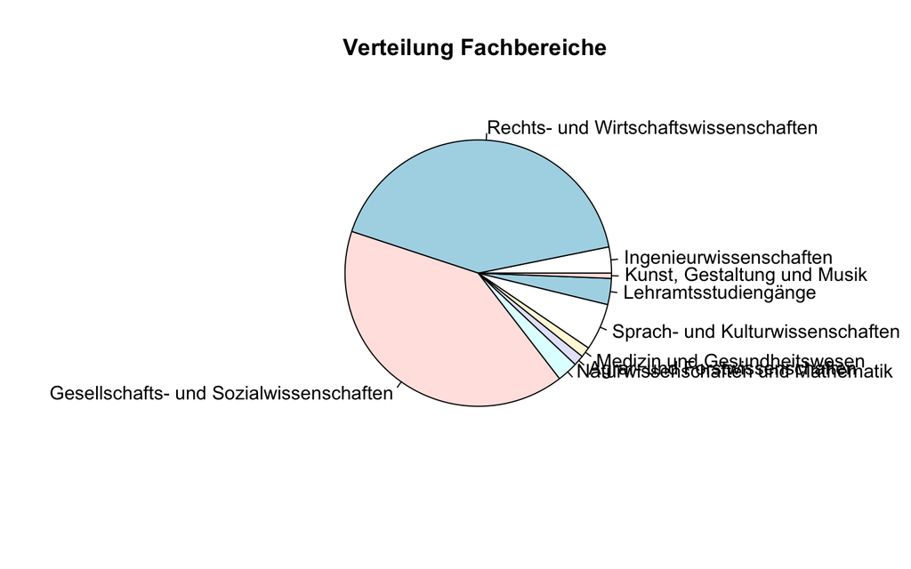

```r
# Studiengänge gruppiert
labels <- unique(data$STUD_CAT)
count_studiengaenge_cat <- c()

for (label in labels) {
    count_studiengaenge_cat[label] <- nrow(subset(data, STUD_CAT == label))
}

pie(count_studiengaenge_cat, main = "Verteilung Fachbereiche ", labels = labels)
```

### Art des Studiengangs

Die Verteilung zwischen Bachelor und Master - Studiengängen soll analysiert werden

```r
# Berechnung Prozentzahlen Bachelor/Master
bachelor_studenten <- subset(data, SD16 == 1)
master_studenten <- subset(data, SD16 == 2)
count_bachelor <- nrow(bachelor_studenten)
count_master <- nrow(master_studenten)
count_bachelor_master <- c(count_bachelor, count_master)
percentages_bachelor_master <- round(count_bachelor_master/sum(count_bachelor_master) *
    100, decimal)
```

Es waren 95 Bachelor- und 63 Master-Studenten in der Stichprobe vorhanden.

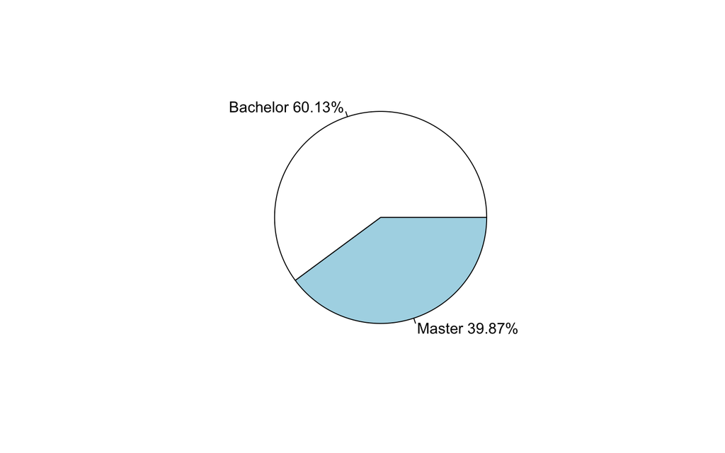

```r
labels <- c("Bachelor", "Master")

labels <- paste(labels, percentages_bachelor_master)
labels <- paste(labels, "%", sep = "")
pie(count_bachelor_master, labels = labels)
```

## Faktoren/Prädiktoren

Jetzt sollen die Faktoren/Prädiktoren beschrieben und analysiert werden.

### Growth Mindset

Der Testwert für das Growth Mindset ergibt sich durch einen Durchschnitt aller Items (Antwortmöglichkeiten 1-5). Dabei müssen jedoch die Items zu einem statischen Mindset rekodiert werden. Dadurch ergibt sich ein Wert zwischen 1 und 5. Die Werte werden hier zur besseren Versändlichkeit zentriert angegeben. Ein negativer Wert bedeutet also ein statisches Mindset, während ein positiver ein dynamisches Mindset. Die Spanne an möglichen Scores reicht also von -2 und 2.

Der Median beträgt dabei 0 und der Mittelwert -0.04. Die Varianz hat dabei einen Wert von 0.71 mit einer Standardabweichung von 0.84.

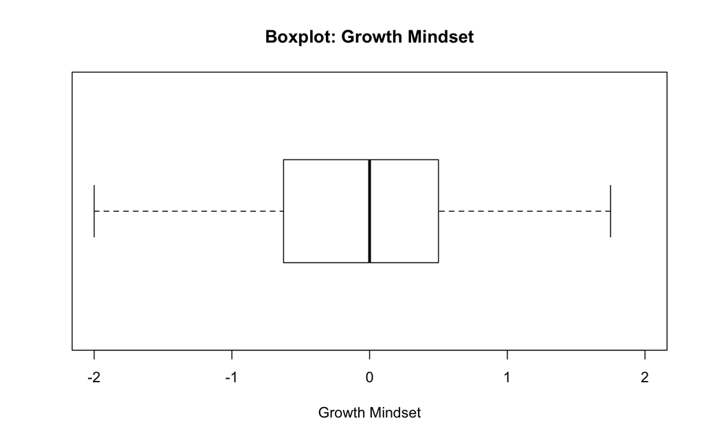

```r
# Boxplot Growth Mindset zentriert
boxplot(MS_CENTERED, main = "Boxplot: Growth Mindset", xlab = "Growth Mindset",
    horizontal = TRUE, ylim = c(borders$MS_CENTERED$MIN, borders$MS_CENTERED$MAX))
```

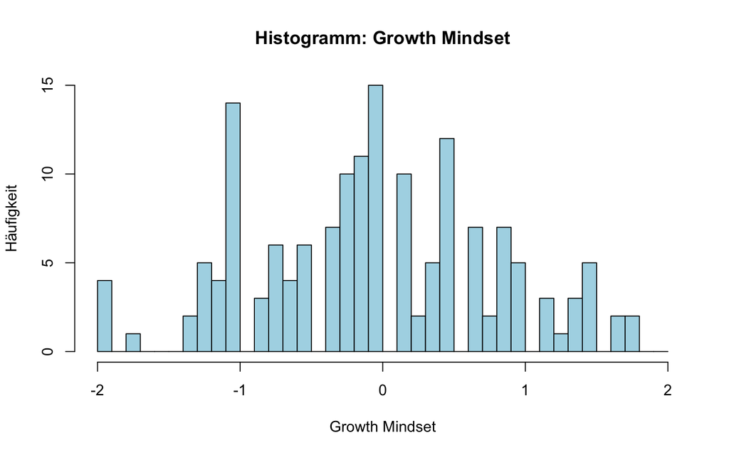

```r
# Histogram Growth Mindset zentriert
hist(MS_CENTERED, breaks = seq(borders$MS_CENTERED$MIN, borders$MS_CENTERED$MAX,
    by = 0.1), main = "Histogramm: Growth Mindset", xlab = "Growth Mindset",
    ylab = "Häufigkeit", col = "lightblue")
```

```r
# Berechnung Cronbachs Alpha für Growth Mindset
alpha_data <- alpha(data[c("MS01_01", "MS01_02", "MS01_03", "MS01_04", "MS01_05",
    "MS01_06", "MS01_07", "MS01_08")], check.keys = TRUE)
```

Cronbachs Alpha beträgt dabei 0.94. Die verwendete Skala ist also in sich konsistent.

### Positive Selbstmotivierung

Der Testwert für die Positiven Selbstmotivierung ergibt sich durch ein Aufsummieren aller Items (Antwortmöglichkeiten 0-3). Es ergeben sich also Werte von 0 bis 12.

Der Median beträgt dabei 6 und der Mittelwert 5.87. Die Varianz hat dabei einen Wert von 5.69 mit einer Standardabweichung von 2.39.

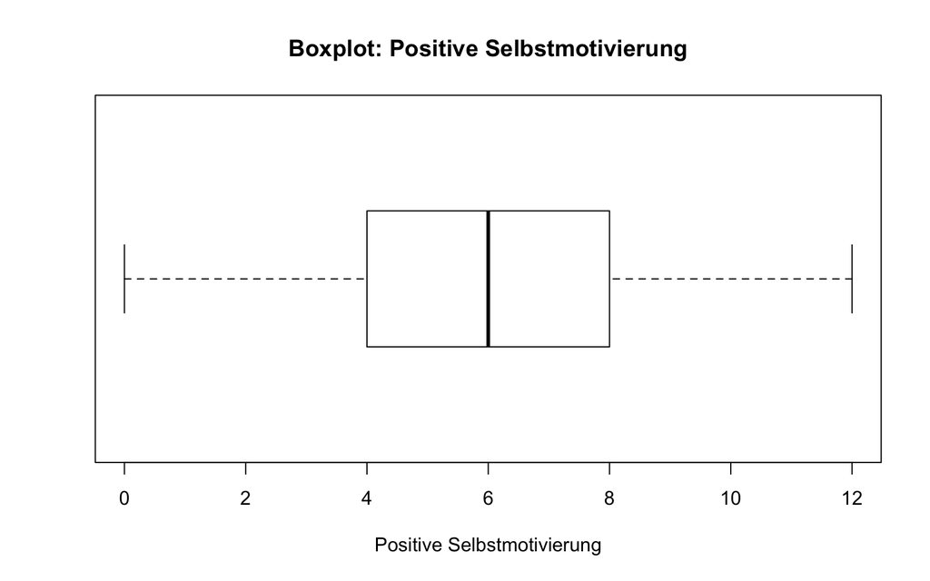

```r
# Boxplot Positive Selbstmotivierung
boxplot(RF, main = "Boxplot: Positive Selbstmotivierung", xlab = "Positive Selbstmotivierung",
    horizontal = TRUE, ylim = c(borders$RF$MIN, borders$RF$MAX))
```

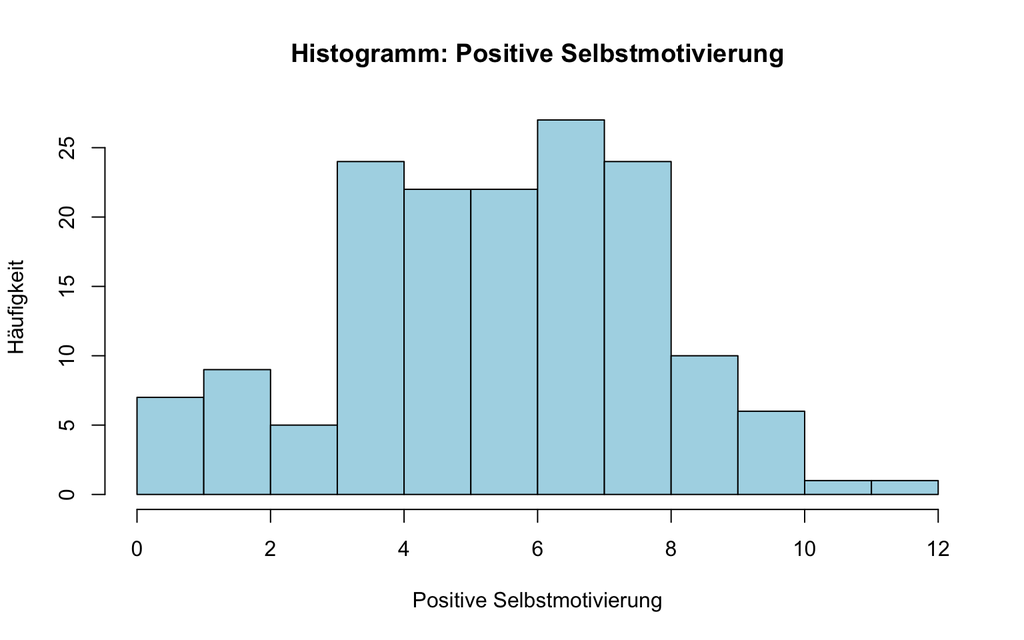

```r
# Histogram Positive Selbstmotivierung
hist(RF, breaks = seq(borders$RF$MIN, borders$RF$MAX, by = 1), main = "Histogramm: Positive Selbstmotivierung",
    xlab = "Positive Selbstmotivierung", ylab = "Häufigkeit", col = "lightblue")
```

```r
# Berechnung Cronbachs alpha
alpha_data <- alpha(data[c("RF01_01", "RF01_02", "RF01_03", "RF01_04")], check.keys = TRUE)
```

Cronbachs Alpha beträgt 0.81. Die verwendete Skala ist also in sich konsistent.

### Produkt von Growth Mindset & Positive Selbstmotivierung

Der Testwert für das Produkt ergibt sich durch Multiplikation von Growth Mindset und Positive Selbstmotivierung. Vor der Bildung des Produkts, wurden jedoch beide Variablen skaliert. Es ergeben sich also ungefähr mögliche Werte in einer Spanne von 0 bis 3.

Der Median beträgt dabei 0.8383648 und der Mittelwert 0.89. Die Varianz hat dabei einen Wert von 0.22 mit einer Standardabweichung von 0.46.

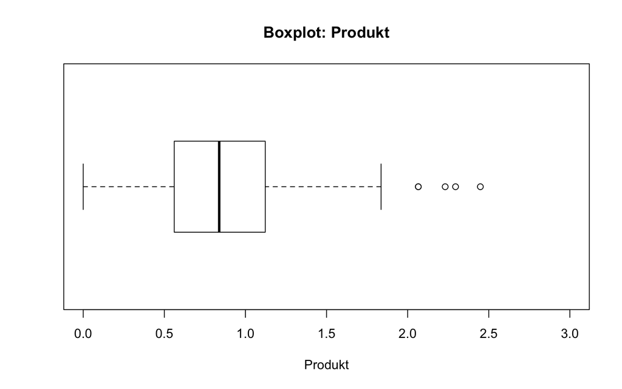

```r
# Boxplot Produkt
boxplot(RF_MS, main = "Boxplot: Produkt", xlab = "Produkt", horizontal = TRUE,
    ylim = c(borders$RF_MS$MIN, borders$RF_MS$MAX))
```

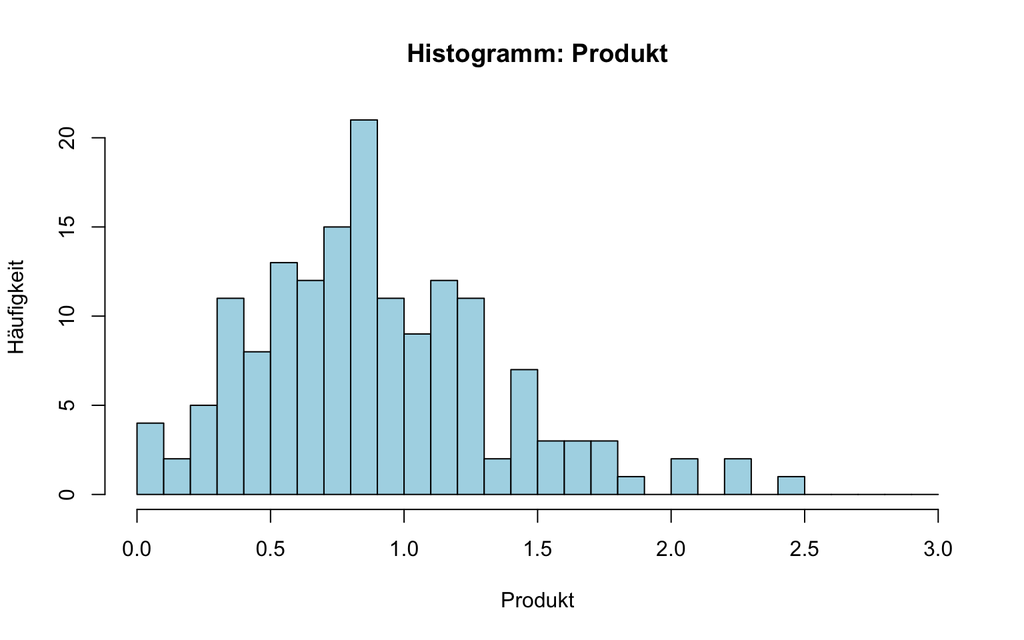

```r
# Histogram Produkt
hist(RF_MS, breaks = seq(borders$RF_MS$MIN, borders$RF_MS$MAX, by = 0.1), main = "Histogramm: Produkt",
    xlab = "Produkt", ylab = "Häufigkeit", col = "lightblue")
```

### Stress

Der Testwert für das Stresslevel ergibt sich durch ein Aufsummieren aller Items (Antwortmöglichkeiten 0-4). Ein höherer Wert bedeutet, also auch ein höheres Stresslevel. Es können sich dabei Werte von 0 bis 40 ergeben.

Der Median beträgt dabei 18 und der Mittelwert 17.58. Die Varianz hat dabei einen Wert von 47.54 mit einer Standardabweichung von 6.9.

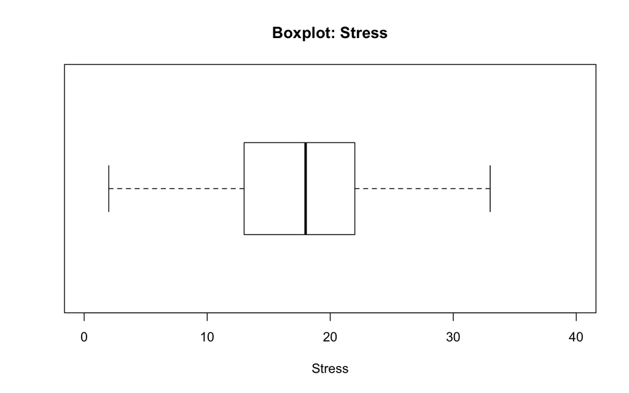

```r
# Boxplot Stress
boxplot(ST, main = "Boxplot: Stress", xlab = "Stress", horizontal = TRUE, ylim = c(borders$ST$MIN,
    borders$ST$MAX))
```

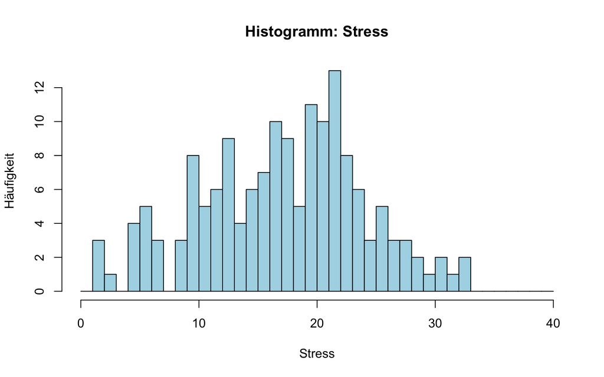

```r
# Histogramm Stress
hist(ST, breaks = seq(borders$ST$MIN, borders$ST$MAX, by = 1), main = "Histogramm: Stress",
    xlab = "Stress", ylab = "Häufigkeit", col = "lightblue")
```

```r
# Berechnung Cronbachs Alpha Stress
alpha_data <- alpha(data[c("ST01_01", "ST01_02", "ST01_03", "ST01_04", "ST01_05",
    "ST01_06", "ST01_07", "ST01_08", "ST01_09", "ST01_10")], check.keys = TRUE)
```

Cronbachs Alpha beträgt 0.87. Die verwendete Skala ist also in sich konsistent.

### Vitalität

Der Testwert für die Vitalität ergibt sich durch einen Durchschnitt aller Items (Antwortmöglichkeiten 1-5). Ein höherer Wert bedeutet, also auch eine höhere Vitalität. Es können sich dabei Werte von 1 bis 5 ergeben.

Der Median beträgt dabei 3 und der Mittelwert 2.96. Die Varianz hat dabei einen Wert von 0.63 mit einer Standardabweichung von 0.79.

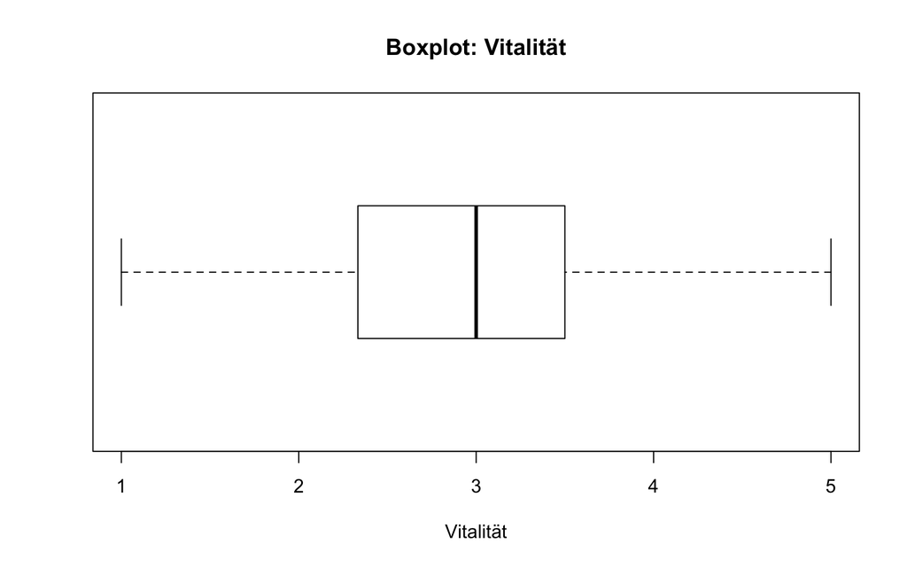

```r
# Boxplot Vitalität
boxplot(VT, main = "Boxplot: Vitalität", xlab = "Vitalität", horizontal = TRUE,
    ylim = c(borders$VT$MIN, borders$VT$MAX))
```

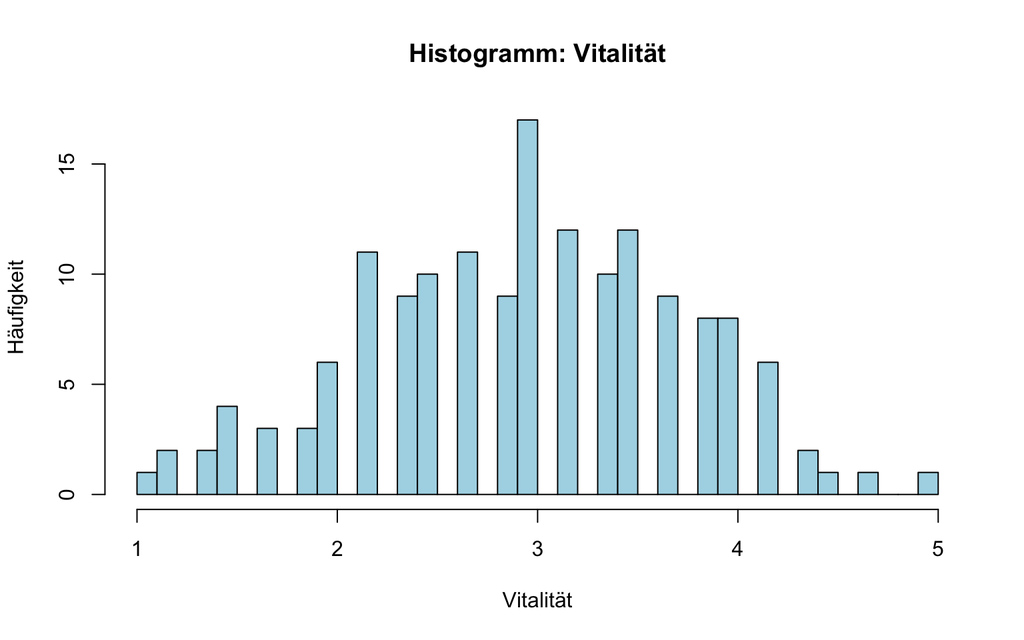

```r
# Histogram Vitalität
hist(VT, breaks = seq(borders$VT$MIN, borders$VT$MAX, by = 0.1), main = "Histogramm: Vitalität",
    xlab = "Vitalität", ylab = "Häufigkeit", col = "lightblue")
```

```r
# Berechnung Cronbachs Alpha Vitalität
alpha_data <- alpha(data[c("VT01_01", "VT01_03", "VT01_04", "VT01_05", "VT01_06",
    "VT01_07")], check.keys = TRUE)
```

Cronbachs Alpha beträgt 0.9. Die verwendete Skala ist also in sich konsistent.

# Korrelation

```r
# gather data
regression_data_1 <- dplyr::select(data, MS, RF, RF_MS, ST)
regression_data_2 <- dplyr::select(data, MS, RF, RF_MS, VT)
```

Es soll nun die Korrelation zwischen den Prädiktoren und den Variablen gezeigt werden.

## Korrelation (Variable: Stress)

```r
# Korrelation Tabelle Stress
labels = c("Growth Mindset", "Positive Selbstmotivierung", "Produkt", "Stress")
cor_1 <- round(cor(regression_data_1), decimal)
rownames(cor_1) <- labels
colnames(cor_1) <- labels

knitr::kable(cor_1, format = "html", table.attr = "class=\"table-th-left\"")
```

|  | Growth Mindset | Positive Selbstmotivierung | Produkt | Stress |
| --- | --- | --- | --- | --- |
| Growth Mindset | 1.00 | 0.04 | 0.58 | 0.06 |
| Positive Selbstmotivierung | 0.04 | 1.00 | 0.79 | -0.37 |
| Produkt | 0.58 | 0.79 | 1.00 | -0.24 |
| Stress | 0.06 | -0.37 | -0.24 | 1.00 |

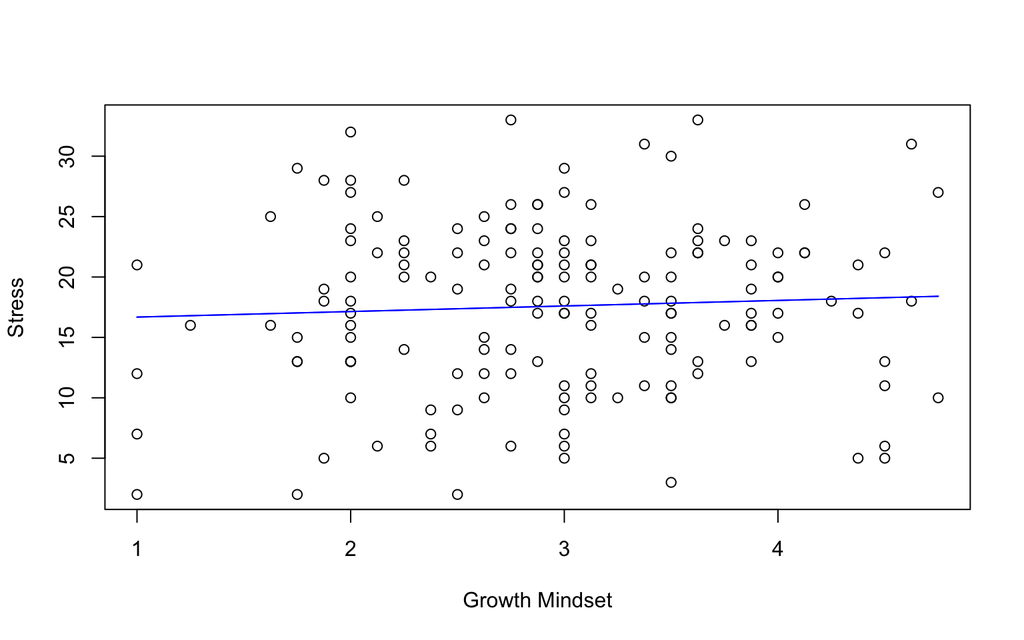

```r
# Plots Stress

# Plot Growth Mindset -> Stress
plot(dplyr::select(data, MS, ST), xlab = "Growth Mindset", ylab = "Stress")
lines(data$MS, fitted(lm(ST ~ MS)), col = "blue")
```

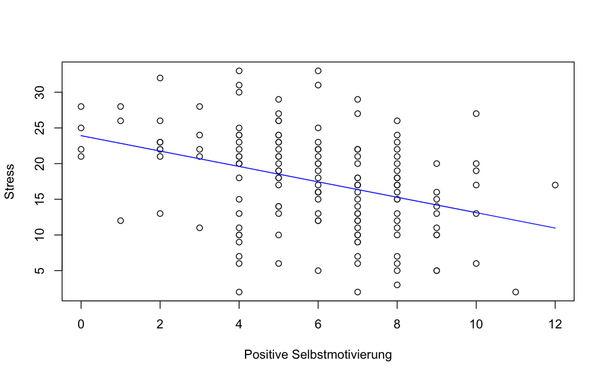

```r
# Plot Positive Selbstmotivierung -> Stress
plot(dplyr::select(data, RF, ST), xlab = "Positive Selbstmotivierung", ylab = "Stress")
lines(data$RF, fitted(lm(ST ~ RF)), col = "blue")
```

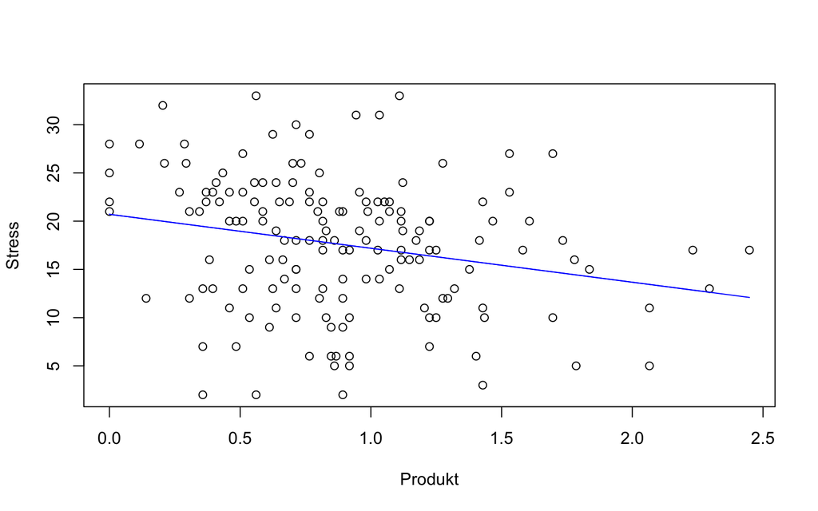

```r
# Plot Produkt -> Stress
plot(dplyr::select(data, RF_MS, ST), xlab = "Produkt", ylab = "Stress")
lines(data$RF_MS, fitted(lm(ST ~ RF_MS)), col = "blue")
```

Man erkennt hier also eine negative Korrelation zwischen Positiver Selbstmotivierung und Stress, während es zwischen dem Growth Mindset und Stress keinen erkennbaren Zusammenhang gibt. Das Produkt zeigt einen schwachen negativen Zusammenhang mit Stress auf.

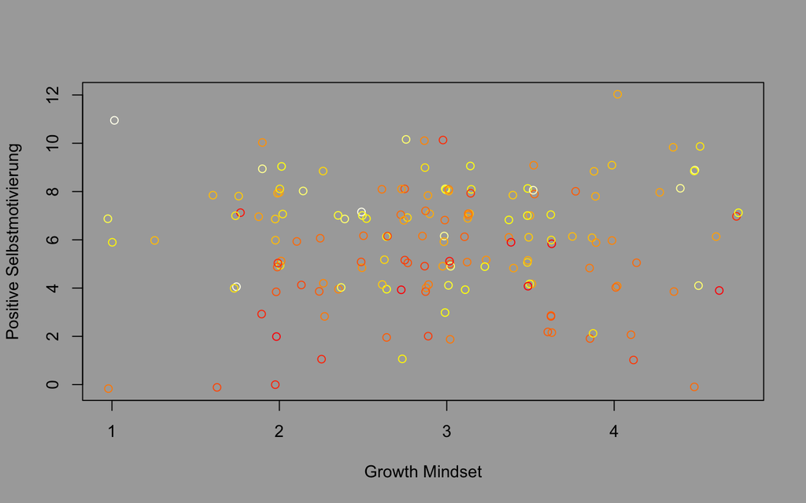

```r
unique_stress_values <- sort(unique(data$ST))
n <- heat_colors <- rev(heat.colors(length(unique_stress_values)))
get_color_by_stress <- function(val) {
    return(heat_colors[which(val == unique_stress_values)])
}
stress_colors <- sapply(data$ST, get_color_by_stress)
par(bg = "darkgrey")
plot(jitter(data$MS), jitter(data$RF), xlab = "Growth Mindset", ylab = "Positive Selbstmotivierung",
    col = stress_colors)
```

Hier sehen wir nocheinmal eine Visualisierung von Positiver Selbstmotivierung und Growth Mindset und deren Einfluss auf Stress. Die dargestellten Punkte zeigen einzelne Datensätze an, wobei eine rote Farbe ein höheres Stresslevel kennzeichnet und eine hellere Farbe ein niedrigeres. Hier lässt sich auch die bereits gefundene Korrelation erkennen, da tendenziell weiter oben hellere Farben vorherrschend sind, während im unteren Bereich dunklere Farben dominant sind. Entlang der x-Achse (also anhand des Growth Mindsets) lassen sich aber keine Unterschiede erkennen.

## Korrelation (Variable: Vitalität)

```r
# Korrelation Tabelle Vitalität
labels = c("Growth Mindset", "Positive Selbstmotivierung", "Produkt", "Vitalität")
cor_2 <- round(cor(regression_data_2), decimal)
rownames(cor_2) <- labels
colnames(cor_2) <- labels

knitr::kable(cor_2, format = "html", table.attr = "class=\"table-th-left\"")
```

|  | Growth Mindset | Positive Selbstmotivierung | Produkt | Vitalität |
| --- | --- | --- | --- | --- |
| Growth Mindset | 1.00 | 0.04 | 0.58 | 0.07 |
| Positive Selbstmotivierung | 0.04 | 1.00 | 0.79 | 0.47 |
| Produkt | 0.58 | 0.79 | 1.00 | 0.37 |
| Vitalität | 0.07 | 0.47 | 0.37 | 1.00 |

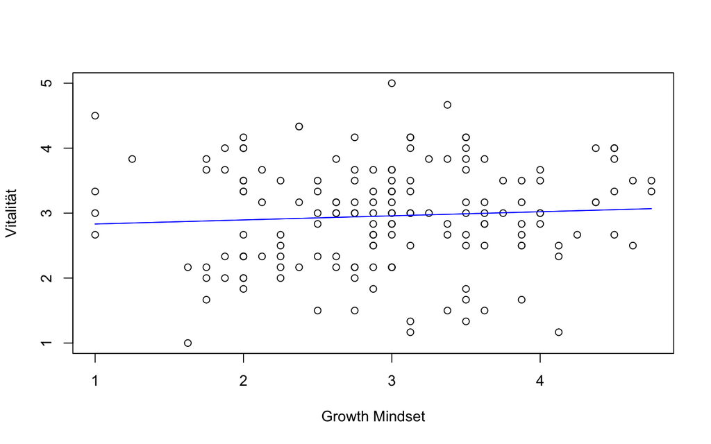

```r
# Plots Vitalität

# Plot Growth Mindset -> Vitalität
plot(dplyr::select(data, MS, VT), xlab = "Growth Mindset", ylab = "Vitalität")
lines(data$MS, fitted(lm(VT ~ MS)), col = "blue")
```

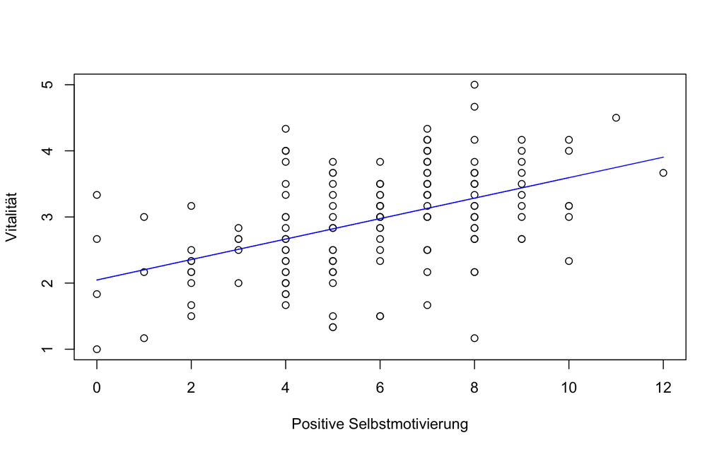

```r
# Plot Positive Selbstmotivierung -> Vitalität
plot(dplyr::select(data, RF, VT), xlab = "Positive Selbstmotivierung", ylab = "Vitalität")
lines(data$RF, fitted(lm(VT ~ RF)), col = "blue")
```

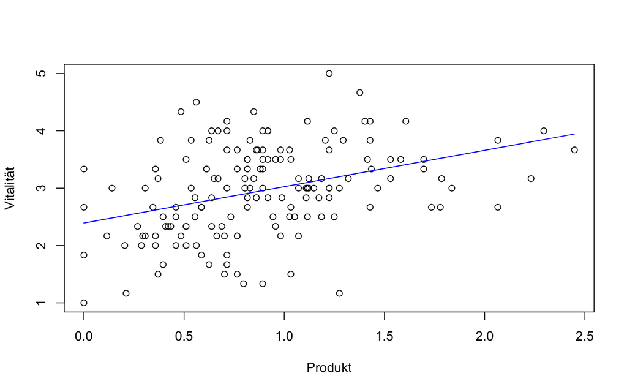

```r
# Plot Produkt -> Vitalität
plot(dplyr::select(data, RF_MS, VT), xlab = "Produkt", ylab = "Vitalität")
lines(data$RF_MS, fitted(lm(VT ~ RF_MS)), col = "blue")
```

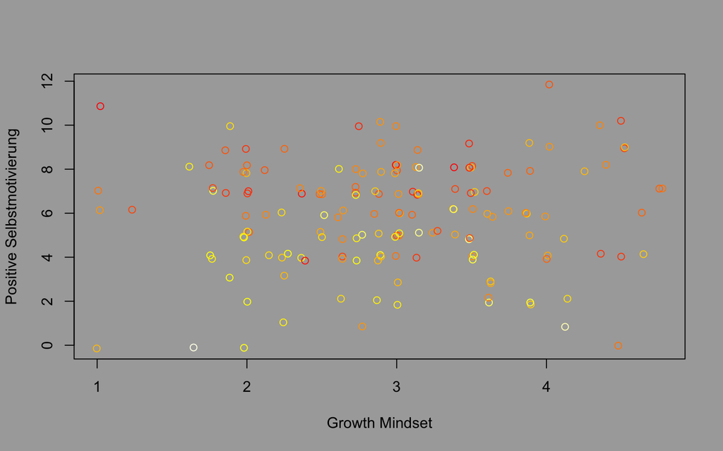

```r
unique_vitality_values <- sort(unique(data$VT))
heat_colors <- rev(heat.colors(length(unique_vitality_values)))
get_color_by_vitality <- function(val) {
    return(heat_colors[which(val == unique_vitality_values)])
}
vitality_colors <- sapply(data$VT, get_color_by_vitality)
par(bg = "darkgrey")
plot(jitter(data$MS), jitter(data$RF), xlab = "Growth Mindset", ylab = "Positive Selbstmotivierung",
    col = vitality_colors)
```

Hier sehen wir nocheinmal eine Visualisierung von Positiver Selbstmotivierung und Growth Mindset und deren Einfluss auf Vitalität Die dargestellten Punkte zeigen einzelne Datensätze an, wobei eine rote Farbe eine höhere Vitalität kennzeichnet und eine hellere Farbe eine niedrigere. Hier lässt sich auch die bereits gefundene Korrelation erkennen, da tendenziell weiter oben dunklere Farben vorherrschend sind, während im unteren Bereich hellere Farben dominant sind. Entlang der x-Achse (also anhand des Growth Mindsets) lassen sich aber keine Unterschiede erkennen.

# Regressionsanalyse

Nun soll versucht werden einen Zusammenhang zwischen Prädiktoren und Variablen mittels Regressionsanalysen herzustellen.

```r
# Standardize regression_data
regression_data_1_scaled <- data.frame(scale(regression_data_1))
regression_data_2_scaled <- data.frame(scale(regression_data_2))
regression_data_1_test <- regression_data_1
```

## Multiple Regression (Variable: Stress)

Zuerst wird als abhängige Variable Stress gewählt. Die unabhängigen Variablen sind dabei das Growth Mindset (MS), die positive Selbstmotivierung (RF) und das Produkt aus beiden (RF_MS).

```r
# Berechnung Model 1: Stress
model1 <- lm(ST ~ MS + RF + RF_MS, data = regression_data_1_scaled)
summary(model1)
```

```
##
## Call:
## lm(formula = ST ~ MS + RF + RF_MS, data = regression_data_1_scaled)
##
## Residuals:
##      Min       1Q   Median       3Q      Max
## -2.52635 -0.63664  0.07903  0.63253  2.20130
##
## Coefficients:
##               Estimate Std. Error t value Pr(>|t|)
## (Intercept)  3.778e-17  7.405e-02   0.000  1.00000
## MS          -8.922e-02  1.699e-01  -0.525  0.60015
## RF          -5.998e-01  2.277e-01  -2.634  0.00929 **
## RF_MS        2.897e-01  2.784e-01   1.040  0.29974
## ---
## Signif. codes:  0 '***' 0.001 '**' 0.01 '*' 0.05 '.' 0.1 ' ' 1
##
## Residual standard error: 0.9307 on 154 degrees of freedom
## Multiple R-squared:  0.1503, Adjusted R-squared:  0.1337
## F-statistic: 9.078 on 3 and 154 DF,  p-value: 1.432e-05
```

```r
model1_coef <- round(coef(model1), decimal)
```

#### ANOVA

```r
anova(model1)
```

```
## Analysis of Variance Table
##
## Response: ST
##            Df  Sum Sq Mean Sq F value    Pr(>F)
## MS          1   0.497  0.4975  0.5742    0.4497
## RF          1  22.157 22.1567 25.5767 1.194e-06 ***
## RF_MS       1   0.938  0.9379  1.0826    0.2997
## Residuals 154 133.408  0.8663
## ---
## Signif. codes:  0 '***' 0.001 '**' 0.01 '*' 0.05 '.' 0.1 ' ' 1
```

Man erkennt hier also signifikante Ergebnisse beim Einfluss von Positiver Selbstmotivierung auf Stress. Steigt die Positive Selbstmotivierung um 1 Einheit an, so steigt der Stress um -0.6 Einheiten. Wenn das Growth Mindset um 1 Einheit steigt, so steigt auch der Stress um -0.09 Einheiten, jedoch ist dieser Zusammenhang nicht signifikant. Auch der Einfluss des Produkts ist nicht signifikant. Jedoch erklärt dieses Model nur 13.37 Prozent der Daten.

## Multiple Regression (Variable: Vitalität)

Zuerst wird als abhängige Variable Vitalität gewählt. Die unabhängigen Variablen sind dabei das Growth Mindset (MS), die positive Selbstmotivierung (RF) und das Produkt aus beiden (RF_MS).

```r
# Berechnung Model 2 Vitalität
model2 <- lm(VT ~ MS + RF + RF_MS, data = regression_data_2_scaled)
summary(model2)
```

```
##
## Call:
## lm(formula = VT ~ MS + RF + RF_MS, data = regression_data_2_scaled)
##
## Residuals:
##      Min       1Q   Median       3Q      Max
## -2.66785 -0.55000  0.00425  0.62670  2.17654
##
## Coefficients:
##               Estimate Std. Error t value Pr(>|t|)
## (Intercept) -2.089e-16  7.056e-02   0.000 1.000000
## MS           2.458e-01  1.619e-01   1.519 0.130911
## RF           7.388e-01  2.170e-01   3.405 0.000844 ***
## RF_MS       -3.558e-01  2.653e-01  -1.341 0.181818
## ---
## Signif. codes:  0 '***' 0.001 '**' 0.01 '*' 0.05 '.' 0.1 ' ' 1
##
## Residual standard error: 0.887 on 154 degrees of freedom
## Multiple R-squared:  0.2283, Adjusted R-squared:  0.2133
## F-statistic: 15.19 on 3 and 154 DF,  p-value: 1.046e-08
```

```r
model2_coef <- round(coef(model2), decimal)
```

#### ANOVA

```r
anova(model2)
```

```
## Analysis of Variance Table
##
## Response: VT
##            Df  Sum Sq Mean Sq F value    Pr(>F)
## MS          1   0.708   0.708  0.8995    0.3444
## RF          1  33.721  33.721 42.8624 8.272e-10 ***
## RF_MS       1   1.415   1.415  1.7989    0.1818
## Residuals 154 121.156   0.787
## ---
## Signif. codes:  0 '***' 0.001 '**' 0.01 '*' 0.05 '.' 0.1 ' ' 1
```

Man erkennt hier also signifikante Ergebnisse beim Einfluss von Positiver Selbstmotivierung auf Vitalität Steigt die Positive Selbstmotivierung um 1 Einheit an, so steigt die Vitalität um 0.74 Einheiten. Wenn das Growth Mindset um 1 Einheit steigt, so steigt auch die Vitalität um 0.25 Einheiten, jedoch ist dieser Zusammenhang nicht signifikant. Auch der Einfluss des Produkts ist nicht signifikant. Jedoch erklärt dieses Model nur 21.33 Prozent der Daten.

# Testen der einzelnen Hypothesen

```r
# Berechnung Mitten: Mitte zwischen minimal möglichem Wert und maximal
# möglichen Wert
midpoint_RF <- mean(c(borders$RF$MIN, borders$RF$MAX))
midpoint_MS <- mean(c(borders$MS$MIN, borders$MS$MAX))
midpoint_RF_MS <- mean(c(borders$RF_MS$MIN, borders$RF_MS$MAX))
```

Nun sollen noch einmal die einzelnen Hypothesen mittels t-Tests geprüft werden.

## 1. Hypothese: Personen mit einem hohen Growth Mindset empfinden weniger Stress

Es soll getestet werden ob Personen mit einem Growth Mindset (also Werten über der Mitte des möglichen Scores) weniger Stress haben, als Personen, die kein Growth Mindset besitzen.

```r
# T-Test Growth Mindset -> Stress
t.test(subset(data, MS <= midpoint_MS)$ST, subset(data, MS > midpoint_MS)$ST)
```

```
##
##  Welch Two Sample t-test
##
## data:  subset(data, MS <= midpoint_MS)$ST and subset(data, MS > midpoint_MS)$ST
## t = -0.20418, df = 149.65, p-value = 0.8385
## alternative hypothesis: true difference in means is not equal to 0
## 95 percent confidence interval:
##  -2.380956  1.934974
## sample estimates:
## mean of x mean of y
##  17.48913  17.71212
```

Diese Hypothese kann leider nicht verworfen werden, da die Ergebnisse nicht signifikant sind.

## 2. Hypothese: Personen mit einem hohen Growth Mindset empfinden mehr Vitalität

Es soll getestet werden ob sich Personen mit einem Growth Mindset (also Werten über der Mitte des möglichen Scores) vitaler fühlen, als Personen, die kein Growth Mindset besitzen.

```r
# T-Test Growth Mindset -> Vitalität
t.test(subset(data, MS <= midpoint_MS)$VT, subset(data, MS > midpoint_MS)$VT)
```

```
##
##  Welch Two Sample t-test
##
## data:  subset(data, MS <= midpoint_MS)$VT and subset(data, MS > midpoint_MS)$VT
## t = -0.82229, df = 134.51, p-value = 0.4124
## alternative hypothesis: true difference in means is not equal to 0
## 95 percent confidence interval:
##  -0.3624629  0.1495731
## sample estimates:
## mean of x mean of y
##  2.911232  3.017677
```

Diese Hypothese kann leider nicht verworfen werden, da die Ergebnisse nicht signifikant sind.

## 3. Hypothese: Personen, die sich gut selbst motivieren können, empfinden weniger Stress

Es soll getestet werden ob Personen mit guten Selbstmotivierungsfähigkeiten (also Werten über der Mitte des möglichen Scores) weniger Stress haben, als Personen, die keine so guten Selbstmotivierungsfähigkeiten besitzen.

```r
# T-Test Positive Selbstmotivierung -> Stress
t.test(subset(data, RF <= midpoint_RF)$ST, subset(data, RF > midpoint_RF)$ST)
```

```
##
##  Welch Two Sample t-test
##
## data:  subset(data, RF <= midpoint_RF)$ST and subset(data, RF > midpoint_RF)$ST
## t = 4.774, df = 149.78, p-value = 4.257e-06
## alternative hypothesis: true difference in means is not equal to 0
## 95 percent confidence interval:
##  2.882925 6.954560
## sample estimates:
## mean of x mean of y
##  19.73034  14.81159
```

Diese Hypothese kann verworfen werden, da sowohl hier die Ergebnisse signifikant sind, als auch in der eben erfolgten Regressionsanalyse.

## 4. Hypothese: Personen, die sich gut selbst motivieren können, empfinden mehr Vitalität

Es soll getestet werden ob sich Personen mit guten Selbstmotivierungsfähigkeiten (also Werten über der Mitte des möglichen Scores) vitaler fühlen, als Personen, die keine so guten Selbstmotivierungsfähigkeiten besitzen.

```r
# T-Test Positive Selbstmotivierung -> Vitalität
t.test(subset(data, RF <= midpoint_RF)$VT, subset(data, RF > midpoint_RF)$VT)
```

```
##
##  Welch Two Sample t-test
##
## data:  subset(data, RF <= midpoint_RF)$VT and subset(data, RF > midpoint_RF)$VT
## t = -5.9932, df = 148.21, p-value = 1.498e-08
## alternative hypothesis: true difference in means is not equal to 0
## 95 percent confidence interval:
##  -0.9142723 -0.4608566
## sample estimates:
## mean of x mean of y
##  2.655431  3.342995
```

Diese Hypothese kann verworfen werden, da sowohl hier die Ergebnisse signifikant sind, als auch in der eben erfolgten Regressionsanalyse.

## 5. Hypothese: Personen, die ein Growth Mindset haben und sich gut selbstmotivieren können, empfinden weniger Stress

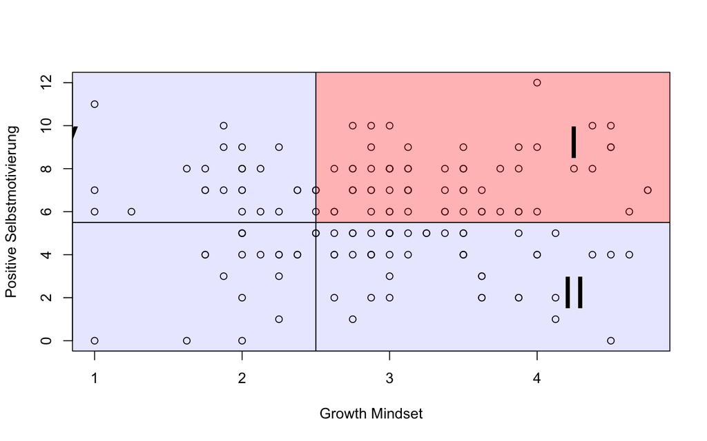

```r
# Generierung PLot Growth Mindset - Positive Selbstmotivierung
plot(dplyr::select(data, MS, RF), xlab = "Growth Mindset", ylab = "Positive Selbstmotivierung")
# Generierung vier Rechtecke für Gruppen
recttext(midpoint_MS - 0.5, midpoint_RF - 0.5, borders$MS$MAX + 1, borders$RF$MAX +
    1, "I", rectArgs = list(col = rgb(1, 0, 0, alpha = 0.3)), textArgs = list(cex = 3))
recttext(midpoint_MS - 0.5, borders$RF$MIN - 1, borders$MS$MAX + 1, midpoint_RF -
    0.5, "II", rectArgs = list(col = rgb(0, 0, 1, alpha = 0.1)), textArgs = list(cex = 3))
recttext(borders$MS$MIN - 2, borders$RF$MIN - 1, midpoint_MS - 0.5, midpoint_RF -
    0.5, "III", rectArgs = list(col = rgb(0, 0, 1, alpha = 0.1)), textArgs = list(cex = 3))
recttext(borders$MS$MIN - 2, midpoint_RF - 0.5, midpoint_MS - 0.5, borders$RF$MAX +
    1, "IV", rectArgs = list(col = rgb(0, 0, 1, alpha = 0.1)), textArgs = list(cex = 3))
```

Es soll getestet werden ob Personen mit Growth Mindset als auch guten Selbstmotivierungsfähigkeiten (also Werten über der Mitte des möglichen Scores) weniger Stress haben, als andere. Man kann die Personen in vier Gruppen aufteilen:

```r
# Generierung Tabelle Gruppierung Erklärung
group_data <- matrix(c("hoch", "hoch", "niedrig", "niedrig", "hoch", "niedrig",
    "niedrig", "hoch"), nrow = 4)
rownames(group_data) <- c("I", "II", "III", "IV")
colnames(group_data) <- c("Growth Mindset", "Positive Selbstmotivierung")

knitr::kable(group_data, format = "html", table.attr = "class=\"table-th-left\"")
```

|  | Growth Mindset | Positive Selbstmotivierung |
| --- | --- | --- |
| I | hoch | hoch |
| II | hoch | niedrig |
| III | niedrig | niedrig |
| IV | niedrig | hoch |

Hierbei vergleichen wir nun also die Gruppe I (rot eingefärbt) mit allen anderen.

```r
# T-Test Beide Werte -> Stress
t.test(subset(data, RF > midpoint_RF & MS > midpoint_MS)$ST, subset(data, !(RF >
    midpoint_RF & MS > midpoint_MS))$ST)
```

```
##
##  Welch Two Sample t-test
##
## data:  subset(data, RF > midpoint_RF & MS > midpoint_MS)$ST and subset(data, !(RF > midpoint_RF & MS > midpoint_MS))$ST
## t = -2.4409, df = 47.239, p-value = 0.01845
## alternative hypothesis: true difference in means is not equal to 0
## 95 percent confidence interval:
##  -5.6151224 -0.5415202
## sample estimates:
## mean of x mean of y
##  15.06897  18.14729
```

## 6. Hypothese: Personen, die ein Growth Mindset haben und sich gut selbstmotivieren können, empfinden mehr Vitalität

Es soll getestet werden ob sich Personen mit Growth Mindset als auch guten Selbstmotivierungsfähigkeiten (also Werten über der Mitte des möglichen Scores) vitaler fühlen, als andere. Die Gruppierung der Personen bleibt, wie bereits eben erläutert, bestehen.

```r
# T-Test Beide Werte -> Stress
t.test(subset(data, RF > midpoint_RF & MS > midpoint_MS)$VT, subset(data, !(RF >
    midpoint_RF & MS > midpoint_MS))$VT)
```

```
##
##  Welch Two Sample t-test
##
## data:  subset(data, RF > midpoint_RF & MS > midpoint_MS)$VT and subset(data, !(RF > midpoint_RF & MS > midpoint_MS))$VT
## t = 3.3277, df = 43.66, p-value = 0.001785
## alternative hypothesis: true difference in means is not equal to 0
## 95 percent confidence interval:
##  0.1989952 0.8105387
## sample estimates:
## mean of x mean of y
##  3.367816  2.863049
```

Diese Hypothese kann verworfen werden, da hier die Ergebnisse signifikant sind.

Jedoch sind ebenjene Ergebnisse in der Regressionsanalyse als nicht signifikant aufgetreten. Dieser Widerspruch lässt sich durch die unterschiedliche Erfassung bzw. Gruppierung erklären. In der Regressionsanalyse wurde nur das einfache Produkt des Growth Mindsets und der Positiven Selbstmotivierung für die Berechnung verwendet. Beim hier vorliegenden T-Test wurde aber die Gruppierung nicht aufgrund des Werts des Produkts getroffen, sondern wirklich nur die Personen untersucht wurden, die hoch auf beiden Skalen scoren (Gruppe I).

Zur Verdeutlichung wird hier nochmals ein t-Test durchgeführt, der das Produkt als Grundlage der Berechnung nutzt.

```r
# T-Test Produkt -> Stress
t.test(subset(data, RF_MS <= midpoint_RF_MS)$ST, subset(data, RF_MS > midpoint_RF_MS)$ST)
```

```
##
##  Welch Two Sample t-test
##
## data:  subset(data, RF_MS <= midpoint_RF_MS)$ST and subset(data, RF_MS > midpoint_RF_MS)$ST
## t = 0.91902, df = 17.295, p-value = 0.3707
## alternative hypothesis: true difference in means is not equal to 0
## 95 percent confidence interval:
##  -2.164824  5.514008
## sample estimates:
## mean of x mean of y
##  17.74126  16.06667
```

```r
# T-Test Produkt -> Vitalität
t.test(subset(data, RF_MS <= midpoint_RF_MS)$VT, subset(data, RF_MS > midpoint_RF_MS)$VT)
```

```
##
##  Welch Two Sample t-test
##
## data:  subset(data, RF_MS <= midpoint_RF_MS)$VT and subset(data, RF_MS > midpoint_RF_MS)$VT
## t = -2.9951, df = 23.801, p-value = 0.006315
## alternative hypothesis: true difference in means is not equal to 0
## 95 percent confidence interval:
##  -0.7049040 -0.1295948
## sample estimates:
## mean of x mean of y
##  2.916084  3.333333
```

# Zusätzliche Analysen

Nun folgen zusätzliche Alternativen, die mögliche weitere Faktoren untersuchen, diese sind jedoch nicht ausführlich dokumentiert.

## Einfluss von weiteren Variablen wie Geschlecht, Alter und Bachelor/Master

# Korrelation

```r
# gather data
regression_data_1 <- dplyr::select(data, MS, RF, SD01, SD02_01, SD16, ST)
regression_data_2 <- dplyr::select(data, MS, RF, SD01, SD02_01, SD16, VT)
```

Es soll nun die Korrelation zwischen den Prädiktoren und den Variablen gezeigt werden.

## Korrelation (Variable: Stress)

```r
labels = c("Growth Mindset", "Positive Selbstmotivierung", "Geschlecht", "Alter",
    "Bachelor/Master", "Stress")
cor_1 <- round(cor(regression_data_1), decimal)
rownames(cor_1) <- labels
colnames(cor_1) <- labels

knitr::kable(cor_1, format = "html", table.attr = "class=\"table-th-left\"")
```

|  | Growth Mindset | Positive Selbstmotivierung | Geschlecht | Alter | Bachelor/Master | Stress |
| --- | --- | --- | --- | --- | --- | --- |
| Growth Mindset | 1.00 | 0.04 | 0.13 | -0.01 | 0.00 | 0.06 |
| Positive Selbstmotivierung | 0.04 | 1.00 | -0.01 | 0.09 | 0.24 | -0.37 |
| Geschlecht | 0.13 | -0.01 | 1.00 | 0.18 | -0.05 | -0.10 |
| Alter | -0.01 | 0.09 | 0.18 | 1.00 | 0.51 | -0.16 |
| Bachelor/Master | 0.00 | 0.24 | -0.05 | 0.51 | 1.00 | -0.20 |
| Stress | 0.06 | -0.37 | -0.10 | -0.16 | -0.20 | 1.00 |

## Korrelation (Variable: Vitalität)

```r
labels = c("Growth Mindset", "Positive Selbstmotivierung", "Geschlecht", "Alter",
    "Bachelor/Master", "Vitalität")
cor_2 <- round(cor(regression_data_2), decimal)
rownames(cor_2) <- labels
colnames(cor_2) <- labels

knitr::kable(cor_2, format = "html", table.attr = "class=\"table-th-left\"")
```

|  | Growth Mindset | Positive Selbstmotivierung | Geschlecht | Alter | Bachelor/Master | Vitalität |
| --- | --- | --- | --- | --- | --- | --- |
| Growth Mindset | 1.00 | 0.04 | 0.13 | -0.01 | 0.00 | 0.07 |
| Positive Selbstmotivierung | 0.04 | 1.00 | -0.01 | 0.09 | 0.24 | 0.47 |
| Geschlecht | 0.13 | -0.01 | 1.00 | 0.18 | -0.05 | 0.08 |
| Alter | -0.01 | 0.09 | 0.18 | 1.00 | 0.51 | 0.05 |
| Bachelor/Master | 0.00 | 0.24 | -0.05 | 0.51 | 1.00 | 0.14 |
| Vitalität | 0.07 | 0.47 | 0.08 | 0.05 | 0.14 | 1.00 |

# Regressionsanalyse

Nun soll versucht werden einen Zusammenhang zwischen Prädiktoren und Variablen mittels Regressionsanalysen herzustellen.

```r
# Standardize regression_data
regression_data_1_scaled <- data.frame(scale(regression_data_1))
regression_data_2_scaled <- data.frame(scale(regression_data_2))
```

## Multiple Regression (Variable: Stress)

```r
model1 <- lm(ST ~ MS + RF + SD01 + SD02_01 + SD16, data = regression_data_1_scaled)
summary(model1)
```

```
##
## Call:
## lm(formula = ST ~ MS + RF + SD01 + SD02_01 + SD16, data = regression_data_1_scaled)
##
## Residuals:
##      Min       1Q   Median       3Q      Max
## -2.37993 -0.53968  0.05757  0.62132  2.33744
##
## Coefficients:
##               Estimate Std. Error t value Pr(>|t|)
## (Intercept)  8.980e-17  7.347e-02   0.000    1.000
## MS           8.210e-02  7.451e-02   1.102    0.272
## RF          -3.514e-01  7.614e-02  -4.616 8.28e-06 ***
## SD01        -1.056e-01  7.680e-02  -1.375    0.171
## SD02_01     -7.128e-02  8.872e-02  -0.803    0.423
## SD16        -8.182e-02  8.964e-02  -0.913    0.363
## ---
## Signif. codes:  0 '***' 0.001 '**' 0.01 '*' 0.05 '.' 0.1 ' ' 1
##
## Residual standard error: 0.9235 on 152 degrees of freedom
## Multiple R-squared:  0.1743, Adjusted R-squared:  0.1471
## F-statistic: 6.418 on 5 and 152 DF,  p-value: 1.94e-05
```

```r
model1_coef <- round(coef(model1), decimal)
```

#### ANOVA

```r
anova(model1)
```

```
## Analysis of Variance Table
##
## Response: ST
##            Df  Sum Sq Mean Sq F value    Pr(>F)
## MS          1   0.497  0.4975  0.5833    0.4462
## RF          1  22.157 22.1567 25.9795 1.012e-06 ***
## SD01        1   2.045  2.0447  2.3975    0.1236
## SD02_01     1   1.957  1.9566  2.2942    0.1319
## SD16        1   0.711  0.7106  0.8332    0.3628
## Residuals 152 129.634  0.8529
## ---
## Signif. codes:  0 '***' 0.001 '**' 0.01 '*' 0.05 '.' 0.1 ' ' 1
```

## Multiple Regression (Variable: Vitalität)

```r
model2 <- lm(VT ~ MS + RF + SD01 + SD02_01 + SD16, data = regression_data_2_scaled)
summary(model2)
```

```
##
## Call:
## lm(formula = VT ~ MS + RF + SD01 + SD02_01 + SD16, data = regression_data_2_scaled)
##
## Residuals:
##      Min       1Q   Median       3Q      Max
## -2.65616 -0.56085  0.01094  0.55277  2.18776
##
## Coefficients:
##               Estimate Std. Error t value Pr(>|t|)
## (Intercept) -2.498e-16  7.107e-02   0.000    1.000
## MS           3.839e-02  7.208e-02   0.533    0.595
## RF           4.574e-01  7.366e-02   6.210 4.82e-09 ***
## SD01         9.013e-02  7.429e-02   1.213    0.227
## SD02_01     -2.511e-02  8.583e-02  -0.293    0.770
## SD16         4.088e-02  8.672e-02   0.471    0.638
## ---
## Signif. codes:  0 '***' 0.001 '**' 0.01 '*' 0.05 '.' 0.1 ' ' 1
##
## Residual standard error: 0.8934 on 152 degrees of freedom
## Multiple R-squared:  0.2273, Adjusted R-squared:  0.2019
## F-statistic: 8.942 on 5 and 152 DF,  p-value: 1.824e-07
```

```r
model2_coef <- round(coef(model2), decimal)
```

#### ANOVA

```r
anova(model2)
```

```
## Analysis of Variance Table
##
## Response: VT
##            Df  Sum Sq Mean Sq F value    Pr(>F)
## MS          1   0.708   0.708  0.8866    0.3479
## RF          1  33.721  33.721 42.2499 1.088e-09 ***
## SD01        1   1.076   1.076  1.3476    0.2475
## SD02_01     1   0.002   0.002  0.0026    0.9593
## SD16        1   0.177   0.177  0.2223    0.6380
## Residuals 152 121.316   0.798
## ---
## Signif. codes:  0 '***' 0.001 '**' 0.01 '*' 0.05 '.' 0.1 ' ' 1
```

## Unterschiede zwischen Bachelor und Master

Herbst et al. (2014) haben bereits einen Unterschied beim Stresslevel zwischen Bachelor und Master Studenten festgestellt. Das soll nun nochmals überprüft werden.

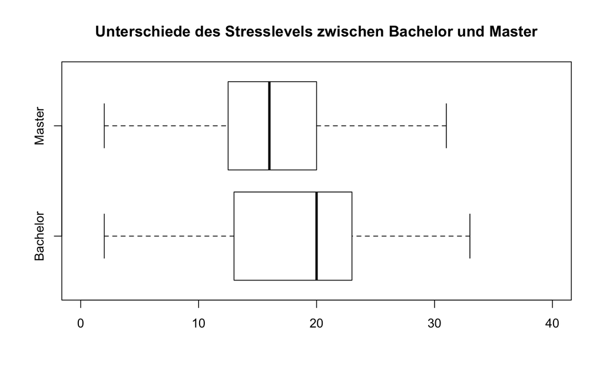

```r
boxplot(bachelor_studenten$ST, master_studenten$ST, names = c("Bachelor", "Master"),
    main = "Unterschiede des Stresslevels zwischen Bachelor und Master", horizontal = TRUE,
    ylim = c(borders$ST$MIN, borders$ST$MAX))
```

Hier lässt sich bereits erkennen, dass Bachelor-Studenten ein größeres Stresslevel haben als Master-Studierende.

```r
t.test(bachelor_studenten$ST, master_studenten$ST)
```

```
##
##  Welch Two Sample t-test
##
## data:  bachelor_studenten$ST and master_studenten$ST
## t = 2.6008, df = 144.21, p-value = 0.01027
## alternative hypothesis: true difference in means is not equal to 0
## 95 percent confidence interval:
##  0.6696521 4.9102978
## sample estimates:
## mean of x mean of y
##  18.69474  15.90476
```

Der durchgeführte t-Test zeigt auch, dass der Unterschied im Stresslevel zwischen Bachelor und Master Studenten signifikant ist.

Dies drängt die Frage auf ob es noch weitere Unterschiede bei den anderen Variablen gibt.

```r
t.test(bachelor_studenten$VT, master_studenten$VT)
```

```
##
##  Welch Two Sample t-test
##
## data:  bachelor_studenten$VT and master_studenten$VT
## t = -1.6756, df = 123.86, p-value = 0.09633
## alternative hypothesis: true difference in means is not equal to 0
## 95 percent confidence interval:
##  -0.47742651  0.03966544
## sample estimates:
## mean of x mean of y
##  2.868421  3.087302
```

```r
t.test(bachelor_studenten$MS, master_studenten$MS)
```

```
##
##  Welch Two Sample t-test
##
## data:  bachelor_studenten$MS and master_studenten$MS
## t = -0.058851, df = 118.48, p-value = 0.9532
## alternative hypothesis: true difference in means is not equal to 0
## 95 percent confidence interval:
##  -0.2894509  0.2727425
## sample estimates:
## mean of x mean of y
##  2.953947  2.962302
```

Sowohl die Unterschiede beim Mindset als auch bei der Vitalität sind nicht signifikant

```r
t.test(bachelor_studenten$RF, master_studenten$RF)
```

```
##
##  Welch Two Sample t-test
##
## data:  bachelor_studenten$RF and master_studenten$RF
## t = -3.3154, df = 152.31, p-value = 0.001144
## alternative hypothesis: true difference in means is not equal to 0
## 95 percent confidence interval:
##  -1.8948197 -0.4797834
## sample estimates:
## mean of x mean of y
##  5.400000  6.587302
```

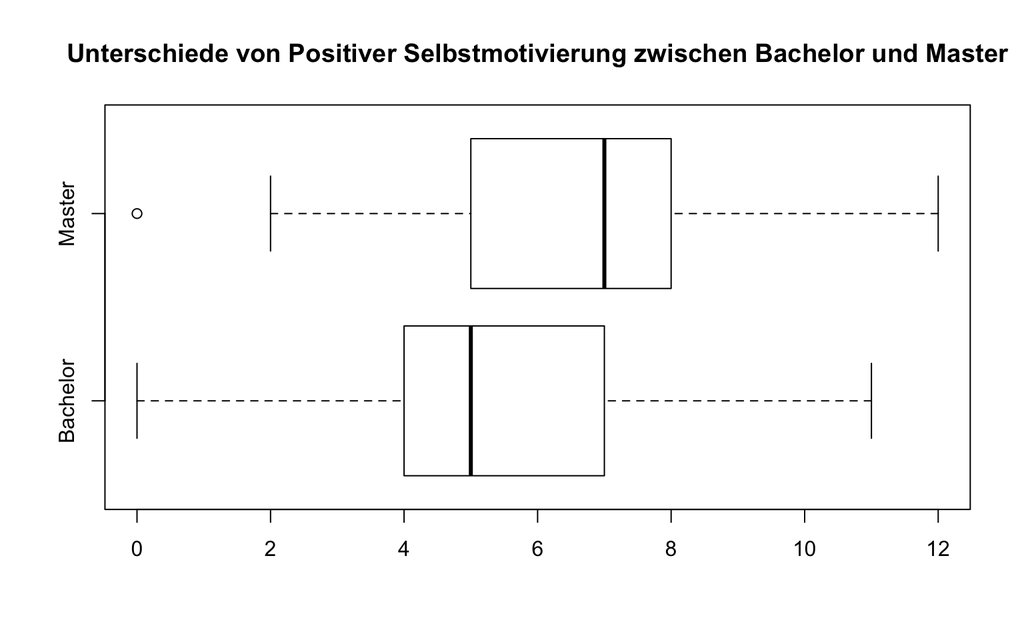

```r
boxplot(bachelor_studenten$RF, master_studenten$RF, names = c("Bachelor", "Master"),
    main = "Unterschiede von Positiver Selbstmotivierung zwischen Bachelor und Master",
    horizontal = TRUE, ylim = c(borders$RF$MIN, borders$RF$MAX))
```

## Unterschiede zwischen den Geschlechtern

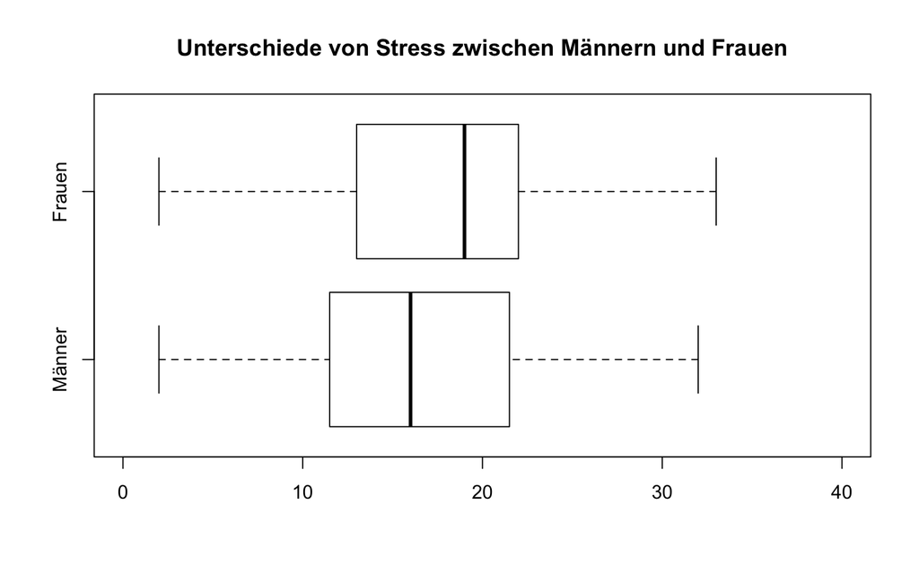

```r
boxplot(men$ST, women$ST, names = c("Männer", "Frauen"), main = "Unterschiede von Stress zwischen Männern und Frauen",
    horizontal = TRUE, ylim = c(borders$ST$MIN, borders$ST$MAX))
```

Auch hier lässt sich ein Unterschie dim Stress level zwischen Männern und Frauen erahnen.

```r
t.test(men$ST, women$ST)
```

```
##
##  Welch Two Sample t-test
##
## data:  men$ST and women$ST
## t = -1.2252, df = 83.239, p-value = 0.2239
## alternative hypothesis: true difference in means is not equal to 0
## 95 percent confidence interval:
##  -3.9220395  0.9318152
## sample estimates:
## mean of x mean of y
##  16.53191  18.02703
```

Dieser Unterschied ist jedoch nicht signifikant.

```r
t.test(men$VT, women$VT)
```

```
##
##  Welch Two Sample t-test
##
## data:  men$VT and women$VT
## t = 1.0765, df = 93.356, p-value = 0.2845
## alternative hypothesis: true difference in means is not equal to 0
## 95 percent confidence interval:
##  -0.1214660  0.4091154
## sample estimates:
## mean of x mean of y
##  3.056738  2.912913
```

```r
t.test(men$RF, women$RF)
```

```
##
##  Welch Two Sample t-test
##
## data:  men$RF and women$RF
## t = -0.14959, df = 87.299, p-value = 0.8814
## alternative hypothesis: true difference in means is not equal to 0
## 95 percent confidence interval:
##  -0.8872758  0.7630665
## sample estimates:
## mean of x mean of y
##  5.829787  5.891892
```

```r
t.test(men$MS, women$MS)
```

```
##
##  Welch Two Sample t-test
##
## data:  men$MS and women$MS
## t = 1.5985, df = 79.875, p-value = 0.1139
## alternative hypothesis: true difference in means is not equal to 0
## 95 percent confidence interval:
##  -0.05941095  0.54445982
## sample estimates:
## mean of x mean of y
##  3.127660  2.885135
```

Auch in Bezug auf die anderen Variablen lassen sich keine signifikanten Unterschiede zwischen Männern und Frauen feststellen.

## Zusammenhang zwischen Stress und Vitalität

Der Zusammenhang zwischen Stress und Vitalität soll ebenfalls untersucht werden

```r
cor_ST_VT <- round(cor(data$ST, data$VT), decimal)
cor.test(data$ST, data$VT)
```

```
##
##  Pearson's product-moment correlation
##
## data:  data$ST and data$VT
## t = -8.1978, df = 156, p-value = 8.396e-14
## alternative hypothesis: true correlation is not equal to 0
## 95 percent confidence interval:
##  -0.6492323 -0.4293621
## sample estimates:
##        cor
## -0.5487161
```

Stress ist mit Vitalität negativ korreliert (-0.55). Diese Korrelation ist auch signifikant.

##### *Fragen? E-Mail an b.wittmann@tum.de*